# Evolutionary Genomics & Bioinformatics

Julia Sousa

8/24/2020

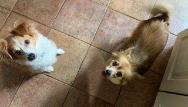

These are my dogs, Sonny and Penny!

# Labs

- Lab 1: Introduction to R and Reproducible Research
- Lab 2: git, GitHub and Reproducible Research
- Lab 3A: Starting with the Data
- Lab 3B: Manipulating Data
- Lab 4: Data Wrangling and Graphing COVID-19 Reporting Data, Part 1
- Lab 5: Data Wrangling and Graphing COVID-19 Reporting Data, Part 2
- Tutorial: Data Visualization Tutorial
- Lab 5x: Lab Extra: Interactive Graphs and Animations from the COVID-19 Reporting Data
- Lab 6: Data Maps and Interactive Graphs from the COVID-19 Reporting Data
- Lab 7: RNA-Seq Qorkflow: gene-level exploratory analysis and differential expression
- Lab 8: Sequence Alignment, Phylogenetic Analysis and Tree Visualization
- Lab 9: Programming in R- Regular Expressions
- Lab 9x: Programming in R- Control Structures and Functions
- Lab 10: Population genetics based on high throughput sequencing (HTS)
- Lab 11: Microbiome Analysis using dada2 and phyloseq
- Lab 11x: Microbiome Aaalysis using phyloseq
- Lab 12: Network Analysis using Cytoscape and RCy3
- Lab 13: Sprucing up your Rmarkdown and GitHub Page